# Risk Factor Analysis

## Outcome Variable

**Outcome Variable:** stunted

## Predictor Variables

**Intervention Variable:** nrooms

**Adjustment Set:**

unadjusted

## Stratifying Variables

The analysis was stratified on these variable(s):

- agecat
- studyid
- country

## Data Summary

| agecat | studyid | country | A | n | nA | nAY0 | nAY1 |
| --- | --- | --- | --- | --- | --- | --- | --- |
| Birth | ki0047075b-MAL-ED | BANGLADESH | 1 | 234 | 144 | 116 | 28 |
| Birth | ki0047075b-MAL-ED | BANGLADESH | 2 | 234 | 50 | 42 | 8 |
| Birth | ki0047075b-MAL-ED | BANGLADESH | 3 | 234 | 28 | 26 | 2 |
| Birth | ki0047075b-MAL-ED | BANGLADESH | 4+ | 234 | 12 | 12 | 0 |
| Birth | ki0047075b-MAL-ED | BRAZIL | 1 | 174 | 3 | 3 | 0 |
| Birth | ki0047075b-MAL-ED | BRAZIL | 2 | 174 | 19 | 18 | 1 |
| Birth | ki0047075b-MAL-ED | BRAZIL | 3 | 174 | 50 | 43 | 7 |
| Birth | ki0047075b-MAL-ED | BRAZIL | 4+ | 174 | 102 | 93 | 9 |
| Birth | ki0047075b-MAL-ED | INDIA | 1 | 191 | 69 | 63 | 6 |
| Birth | ki0047075b-MAL-ED | INDIA | 2 | 191 | 68 | 51 | 17 |
| Birth | ki0047075b-MAL-ED | INDIA | 3 | 191 | 32 | 27 | 5 |
| Birth | ki0047075b-MAL-ED | INDIA | 4+ | 191 | 22 | 20 | 2 |
| Birth | ki0047075b-MAL-ED | NEPAL | 1 | 171 | 36 | 33 | 3 |
| Birth | ki0047075b-MAL-ED | NEPAL | 2 | 171 | 21 | 20 | 1 |
| Birth | ki0047075b-MAL-ED | NEPAL | 3 | 171 | 17 | 13 | 4 |
| Birth | ki0047075b-MAL-ED | NEPAL | 4+ | 171 | 97 | 87 | 10 |
| Birth | ki0047075b-MAL-ED | PERU | 1 | 259 | 17 | 16 | 1 |
| Birth | ki0047075b-MAL-ED | PERU | 2 | 259 | 51 | 47 | 4 |
| Birth | ki0047075b-MAL-ED | PERU | 3 | 259 | 59 | 54 | 5 |
| Birth | ki0047075b-MAL-ED | PERU | 4+ | 259 | 132 | 111 | 21 |
| Birth | ki0047075b-MAL-ED | SOUTH AFRICA | 1 | 218 | 14 | 14 | 0 |
| Birth | ki0047075b-MAL-ED | SOUTH AFRICA | 2 | 218 | 21 | 19 | 2 |
| Birth | ki0047075b-MAL-ED | SOUTH AFRICA | 3 | 218 | 23 | 21 | 2 |
| Birth | ki0047075b-MAL-ED | SOUTH AFRICA | 4+ | 218 | 160 | 142 | 18 |
| Birth | ki0047075b-MAL-ED | TANZANIA, UNITED REPUBLIC OF | 1 | 118 | 6 | 6 | 0 |
| Birth | ki0047075b-MAL-ED | TANZANIA, UNITED REPUBLIC OF | 2 | 118 | 24 | 19 | 5 |
| Birth | ki0047075b-MAL-ED | TANZANIA, UNITED REPUBLIC OF | 3 | 118 | 33 | 29 | 4 |
| Birth | ki0047075b-MAL-ED | TANZANIA, UNITED REPUBLIC OF | 4+ | 118 | 55 | 48 | 7 |
| Birth | ki1000108-CMC-V-BCS-2002 | INDIA | 1 | 90 | 38 | 32 | 6 |
| Birth | ki1000108-CMC-V-BCS-2002 | INDIA | 2 | 90 | 28 | 22 | 6 |

[output cut: 350 more lines]

The following strata were considered:

- agecat: 12 months, studyid: ki0047075b-MAL-ED, country: BANGLADESH
- agecat: 12 months, studyid: ki0047075b-MAL-ED, country: BRAZIL
- agecat: 12 months, studyid: ki0047075b-MAL-ED, country: INDIA
- agecat: 12 months, studyid: ki0047075b-MAL-ED, country: NEPAL
- agecat: 12 months, studyid: ki0047075b-MAL-ED, country: PERU
- agecat: 12 months, studyid: ki0047075b-MAL-ED, country: SOUTH AFRICA
- agecat: 12 months, studyid: ki0047075b-MAL-ED, country: TANZANIA, UNITED REPUBLIC OF
- agecat: 12 months, studyid: ki1000108-CMC-V-BCS-2002, country: INDIA
- agecat: 12 months, studyid: ki1000108-IRC, country: INDIA
- agecat: 12 months, studyid: ki1017093b-PROVIDE, country: BANGLADESH
- agecat: 12 months, studyid: ki1017093c-NIH-Crypto, country: BANGLADESH
- agecat: 12 months, studyid: ki1113344-GMS-Nepal, country: NEPAL
- agecat: 12 months, studyid: ki1114097-CONTENT, country: PERU
- agecat: 12 months, studyid: ki1135781-COHORTS, country: INDIA
- agecat: 18 months, studyid: ki0047075b-MAL-ED, country: BANGLADESH
- agecat: 18 months, studyid: ki0047075b-MAL-ED, country: BRAZIL
- agecat: 18 months, studyid: ki0047075b-MAL-ED, country: INDIA
- agecat: 18 months, studyid: ki0047075b-MAL-ED, country: NEPAL
- agecat: 18 months, studyid: ki0047075b-MAL-ED, country: PERU
- agecat: 18 months, studyid: ki0047075b-MAL-ED, country: SOUTH AFRICA
- agecat: 18 months, studyid: ki0047075b-MAL-ED, country: TANZANIA, UNITED REPUBLIC OF
- agecat: 18 months, studyid: ki1000108-CMC-V-BCS-2002, country: INDIA
- agecat: 18 months, studyid: ki1000108-IRC, country: INDIA
- agecat: 18 months, studyid: ki1017093b-PROVIDE, country: BANGLADESH
- agecat: 18 months, studyid: ki1017093c-NIH-Crypto, country: BANGLADESH
- agecat: 18 months, studyid: ki1113344-GMS-Nepal, country: NEPAL
- agecat: 18 months, studyid: ki1114097-CONTENT, country: PERU
- agecat: 24 months, studyid: ki0047075b-MAL-ED, country: BANGLADESH
- agecat: 24 months, studyid: ki0047075b-MAL-ED, country: BRAZIL
- agecat: 24 months, studyid: ki0047075b-MAL-ED, country: INDIA
- agecat: 24 months, studyid: ki0047075b-MAL-ED, country: NEPAL
- agecat: 24 months, studyid: ki0047075b-MAL-ED, country: PERU
- agecat: 24 months, studyid: ki0047075b-MAL-ED, country: SOUTH AFRICA
- agecat: 24 months, studyid: ki0047075b-MAL-ED, country: TANZANIA, UNITED REPUBLIC OF
- agecat: 24 months, studyid: ki1000108-CMC-V-BCS-2002, country: INDIA
- agecat: 24 months, studyid: ki1000108-IRC, country: INDIA
- agecat: 24 months, studyid: ki1017093b-PROVIDE, country: BANGLADESH
- agecat: 24 months, studyid: ki1017093c-NIH-Crypto, country: BANGLADESH
- agecat: 24 months, studyid: ki1113344-GMS-Nepal, country: NEPAL
- agecat: 24 months, studyid: ki1114097-CONTENT, country: PERU
- agecat: 24 months, studyid: ki1135781-COHORTS, country: INDIA
- agecat: 3 months, studyid: ki0047075b-MAL-ED, country: BANGLADESH
- agecat: 3 months, studyid: ki0047075b-MAL-ED, country: BRAZIL
- agecat: 3 months, studyid: ki0047075b-MAL-ED, country: INDIA
- agecat: 3 months, studyid: ki0047075b-MAL-ED, country: NEPAL
- agecat: 3 months, studyid: ki0047075b-MAL-ED, country: PERU
- agecat: 3 months, studyid: ki0047075b-MAL-ED, country: SOUTH AFRICA
- agecat: 3 months, studyid: ki0047075b-MAL-ED, country: TANZANIA, UNITED REPUBLIC OF
- agecat: 3 months, studyid: ki1000108-CMC-V-BCS-2002, country: INDIA
- agecat: 3 months, studyid: ki1000108-IRC, country: INDIA
- agecat: 3 months, studyid: ki1017093b-PROVIDE, country: BANGLADESH
- agecat: 3 months, studyid: ki1017093c-NIH-Crypto, country: BANGLADESH
- agecat: 3 months, studyid: ki1113344-GMS-Nepal, country: NEPAL
- agecat: 3 months, studyid: ki1114097-CONTENT, country: PERU
- agecat: 3 months, studyid: ki1135781-COHORTS, country: INDIA
- agecat: 6 months, studyid: ki0047075b-MAL-ED, country: BANGLADESH
- agecat: 6 months, studyid: ki0047075b-MAL-ED, country: BRAZIL
- agecat: 6 months, studyid: ki0047075b-MAL-ED, country: INDIA
- agecat: 6 months, studyid: ki0047075b-MAL-ED, country: NEPAL
- agecat: 6 months, studyid: ki0047075b-MAL-ED, country: PERU
- agecat: 6 months, studyid: ki0047075b-MAL-ED, country: SOUTH AFRICA
- agecat: 6 months, studyid: ki0047075b-MAL-ED, country: TANZANIA, UNITED REPUBLIC OF
- agecat: 6 months, studyid: ki1000108-CMC-V-BCS-2002, country: INDIA
- agecat: 6 months, studyid: ki1000108-IRC, country: INDIA
- agecat: 6 months, studyid: ki1017093b-PROVIDE, country: BANGLADESH
- agecat: 6 months, studyid: ki1017093c-NIH-Crypto, country: BANGLADESH
- agecat: 6 months, studyid: ki1113344-GMS-Nepal, country: NEPAL
- agecat: 6 months, studyid: ki1114097-CONTENT, country: PERU
- agecat: 6 months, studyid: ki1135781-COHORTS, country: INDIA
- agecat: 9 months, studyid: ki0047075b-MAL-ED, country: BANGLADESH
- agecat: 9 months, studyid: ki0047075b-MAL-ED, country: BRAZIL
- agecat: 9 months, studyid: ki0047075b-MAL-ED, country: INDIA
- agecat: 9 months, studyid: ki0047075b-MAL-ED, country: NEPAL
- agecat: 9 months, studyid: ki0047075b-MAL-ED, country: PERU
- agecat: 9 months, studyid: ki0047075b-MAL-ED, country: SOUTH AFRICA
- agecat: 9 months, studyid: ki0047075b-MAL-ED, country: TANZANIA, UNITED REPUBLIC OF
- agecat: 9 months, studyid: ki1000108-CMC-V-BCS-2002, country: INDIA
- agecat: 9 months, studyid: ki1000108-IRC, country: INDIA
- agecat: 9 months, studyid: ki1017093b-PROVIDE, country: BANGLADESH
- agecat: 9 months, studyid: ki1017093c-NIH-Crypto, country: BANGLADESH
- agecat: 9 months, studyid: ki1113344-GMS-Nepal, country: NEPAL
- agecat: 9 months, studyid: ki1114097-CONTENT, country: PERU
- agecat: 9 months, studyid: ki1135781-COHORTS, country: INDIA
- agecat: Birth, studyid: ki0047075b-MAL-ED, country: BANGLADESH
- agecat: Birth, studyid: ki0047075b-MAL-ED, country: BRAZIL
- agecat: Birth, studyid: ki0047075b-MAL-ED, country: INDIA
- agecat: Birth, studyid: ki0047075b-MAL-ED, country: NEPAL
- agecat: Birth, studyid: ki0047075b-MAL-ED, country: PERU
- agecat: Birth, studyid: ki0047075b-MAL-ED, country: SOUTH AFRICA
- agecat: Birth, studyid: ki0047075b-MAL-ED, country: TANZANIA, UNITED REPUBLIC OF
- agecat: Birth, studyid: ki1000108-CMC-V-BCS-2002, country: INDIA
- agecat: Birth, studyid: ki1000108-IRC, country: INDIA
- agecat: Birth, studyid: ki1017093c-NIH-Crypto, country: BANGLADESH
- agecat: Birth, studyid: ki1114097-CONTENT, country: PERU
- agecat: Birth, studyid: ki1135781-COHORTS, country: INDIA

### Dropped Strata

Some strata were dropped due to rare outcomes:

- agecat: Birth, studyid: ki0047075b-MAL-ED, country: BANGLADESH
- agecat: Birth, studyid: ki0047075b-MAL-ED, country: BRAZIL
- agecat: Birth, studyid: ki0047075b-MAL-ED, country: INDIA
- agecat: Birth, studyid: ki0047075b-MAL-ED, country: NEPAL
- agecat: Birth, studyid: ki0047075b-MAL-ED, country: PERU
- agecat: Birth, studyid: ki0047075b-MAL-ED, country: SOUTH AFRICA
- agecat: Birth, studyid: ki0047075b-MAL-ED, country: TANZANIA, UNITED REPUBLIC OF
- agecat: Birth, studyid: ki1000108-CMC-V-BCS-2002, country: INDIA
- agecat: Birth, studyid: ki1000108-IRC, country: INDIA
- agecat: Birth, studyid: ki1017093c-NIH-Crypto, country: BANGLADESH
- agecat: Birth, studyid: ki1114097-CONTENT, country: PERU
- agecat: 3 months, studyid: ki0047075b-MAL-ED, country: BANGLADESH
- agecat: 3 months, studyid: ki0047075b-MAL-ED, country: BRAZIL
- agecat: 3 months, studyid: ki0047075b-MAL-ED, country: INDIA
- agecat: 3 months, studyid: ki0047075b-MAL-ED, country: NEPAL
- agecat: 3 months, studyid: ki0047075b-MAL-ED, country: SOUTH AFRICA
- agecat: 3 months, studyid: ki0047075b-MAL-ED, country: TANZANIA, UNITED REPUBLIC OF
- agecat: 3 months, studyid: ki1000108-CMC-V-BCS-2002, country: INDIA
- agecat: 3 months, studyid: ki1017093b-PROVIDE, country: BANGLADESH
- agecat: 3 months, studyid: ki1114097-CONTENT, country: PERU
- agecat: 6 months, studyid: ki0047075b-MAL-ED, country: BANGLADESH
- agecat: 6 months, studyid: ki0047075b-MAL-ED, country: BRAZIL
- agecat: 6 months, studyid: ki0047075b-MAL-ED, country: INDIA
- agecat: 6 months, studyid: ki0047075b-MAL-ED, country: NEPAL
- agecat: 6 months, studyid: ki0047075b-MAL-ED, country: SOUTH AFRICA
- agecat: 6 months, studyid: ki0047075b-MAL-ED, country: TANZANIA, UNITED REPUBLIC OF
- agecat: 6 months, studyid: ki1000108-CMC-V-BCS-2002, country: INDIA
- agecat: 6 months, studyid: ki1000108-IRC, country: INDIA
- agecat: 6 months, studyid: ki1017093b-PROVIDE, country: BANGLADESH
- agecat: 6 months, studyid: ki1114097-CONTENT, country: PERU
- agecat: 9 months, studyid: ki0047075b-MAL-ED, country: BANGLADESH
- agecat: 9 months, studyid: ki0047075b-MAL-ED, country: BRAZIL
- agecat: 9 months, studyid: ki0047075b-MAL-ED, country: INDIA
- agecat: 9 months, studyid: ki0047075b-MAL-ED, country: NEPAL
- agecat: 9 months, studyid: ki0047075b-MAL-ED, country: SOUTH AFRICA
- agecat: 9 months, studyid: ki0047075b-MAL-ED, country: TANZANIA, UNITED REPUBLIC OF
- agecat: 9 months, studyid: ki1017093b-PROVIDE, country: BANGLADESH
- agecat: 9 months, studyid: ki1114097-CONTENT, country: PERU
- agecat: 12 months, studyid: ki0047075b-MAL-ED, country: BANGLADESH
- agecat: 12 months, studyid: ki0047075b-MAL-ED, country: BRAZIL
- agecat: 12 months, studyid: ki0047075b-MAL-ED, country: NEPAL
- agecat: 12 months, studyid: ki0047075b-MAL-ED, country: SOUTH AFRICA
- agecat: 12 months, studyid: ki1017093b-PROVIDE, country: BANGLADESH
- agecat: 12 months, studyid: ki1114097-CONTENT, country: PERU
- agecat: 18 months, studyid: ki0047075b-MAL-ED, country: BANGLADESH
- agecat: 18 months, studyid: ki0047075b-MAL-ED, country: BRAZIL
- agecat: 18 months, studyid: ki0047075b-MAL-ED, country: TANZANIA, UNITED REPUBLIC OF
- agecat: 18 months, studyid: ki1114097-CONTENT, country: PERU
- agecat: 24 months, studyid: ki0047075b-MAL-ED, country: BANGLADESH
- agecat: 24 months, studyid: ki0047075b-MAL-ED, country: BRAZIL
- agecat: 24 months, studyid: ki0047075b-MAL-ED, country: TANZANIA, UNITED REPUBLIC OF
- agecat: 24 months, studyid: ki1114097-CONTENT, country: PERU

## Methods Detail

We’re interested in the causal parameters $E[Y_a]$ for all values of $a \in \mathcal{A}$. These parameters represent the mean outcome if, possibly contrary to fact, we intervened to set all units to have $A=a$. Under the randomization and positivity assumptions, these are identified by the statistical parameters $\psi_a=E_W[E_{Y|A,W}(Y|A=a,W)]$. In addition, we’re interested in the mean of $Y$, $E[Y]$ under no intervention (the observed mean). We will estimate these parameters by using SuperLearner to fit the relevant likelihood factors – $E_{Y|A,W}(Y|A=a,W)$ and $p(A=a|W)$, and then updating our likelihood fit using a joint TMLE.

For unadjusted analyses ($W=\{\}$), initial likelihoods were estimated using Lrnr_glm to estimate the simple $E(Y|A)$ and Lrnr_mean to estimate $p(A)$. For adjusted analyses, a small library containing Lrnr_glmnet, Lrnr_xgboost, and Lrnr_mean was used.

Having estimated these parameters, we will then use the delta method to estimate relative risks and attributable risks relative to a prespecified baseline level of $A$.

# Results Detail

## Results Plots

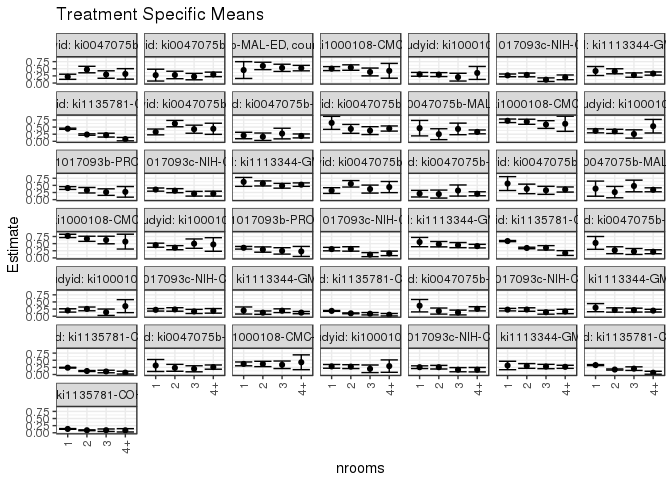

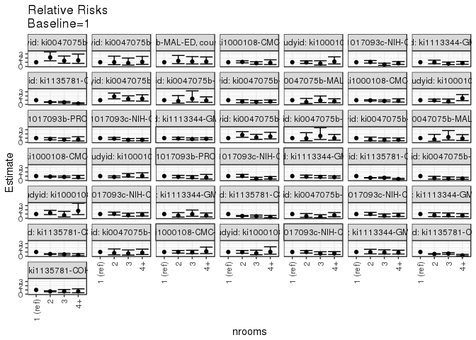

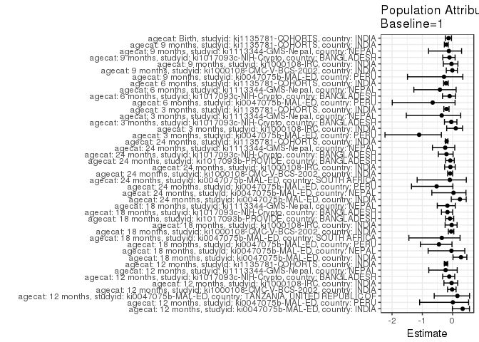

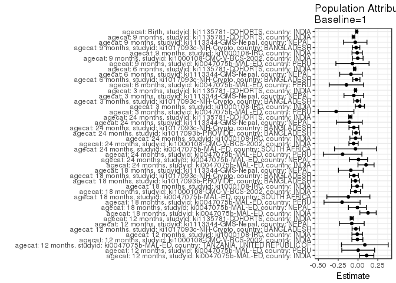

## Results Table

### Parameter: TSM

| agecat | studyid | country | intervention_level | baseline_level | estimate | ci_lower | ci_upper |
| --- | --- | --- | --- | --- | --- | --- | --- |
| Birth | ki1135781-COHORTS | INDIA | 1 | NA | 0.1344000 | 0.1224401 | 0.1463599 |
| Birth | ki1135781-COHORTS | INDIA | 2 | NA | 0.0880866 | 0.0731587 | 0.1030146 |
| Birth | ki1135781-COHORTS | INDIA | 3 | NA | 0.0898204 | 0.0464507 | 0.1331901 |
| Birth | ki1135781-COHORTS | INDIA | 4+ | NA | 0.0869565 | 0.0293732 | 0.1445398 |
| 3 months | ki0047075b-MAL-ED | PERU | 1 | NA | 0.5263158 | 0.3013903 | 0.7512413 |
| 3 months | ki0047075b-MAL-ED | PERU | 2 | NA | 0.2692308 | 0.1484497 | 0.3900118 |
| 3 months | ki0047075b-MAL-ED | PERU | 3 | NA | 0.2258065 | 0.1215399 | 0.3300730 |
| 3 months | ki0047075b-MAL-ED | PERU | 4+ | NA | 0.2158273 | 0.1473101 | 0.2843445 |
| 3 months | ki1000108-IRC | INDIA | 1 | NA | 0.2010870 | 0.1431017 | 0.2590722 |
| 3 months | ki1000108-IRC | INDIA | 2 | NA | 0.2559524 | 0.1898815 | 0.3220233 |
| 3 months | ki1000108-IRC | INDIA | 3 | NA | 0.1388889 | 0.0257799 | 0.2519979 |
| 3 months | ki1000108-IRC | INDIA | 4+ | NA | 0.3529412 | 0.1254925 | 0.5803899 |
| 3 months | ki1017093c-NIH-Crypto | BANGLADESH | 1 | NA | 0.2234957 | 0.1797596 | 0.2672318 |
| 3 months | ki1017093c-NIH-Crypto | BANGLADESH | 2 | NA | 0.2365591 | 0.1754442 | 0.2976741 |
| 3 months | ki1017093c-NIH-Crypto | BANGLADESH | 3 | NA | 0.1666667 | 0.0942931 | 0.2390403 |
| 3 months | ki1017093c-NIH-Crypto | BANGLADESH | 4+ | NA | 0.1868132 | 0.1066777 | 0.2669487 |
| 3 months | ki1113344-GMS-Nepal | NEPAL | 1 | NA | 0.2000000 | 0.0759323 | 0.3240677 |
| 3 months | ki1113344-GMS-Nepal | NEPAL | 2 | NA | 0.1239669 | 0.0651978 | 0.1827361 |
| 3 months | ki1113344-GMS-Nepal | NEPAL | 3 | NA | 0.1928571 | 0.1274451 | 0.2582692 |
| 3 months | ki1113344-GMS-Nepal | NEPAL | 4+ | NA | 0.1259259 | 0.0863183 | 0.1655335 |
| 3 months | ki1135781-COHORTS | INDIA | 1 | NA | 0.1860535 | 0.1728289 | 0.1992781 |
| 3 months | ki1135781-COHORTS | INDIA | 2 | NA | 0.1002045 | 0.0848374 | 0.1155716 |
| 3 months | ki1135781-COHORTS | INDIA | 3 | NA | 0.0864865 | 0.0459789 | 0.1269941 |
| 3 months | ki1135781-COHORTS | INDIA | 4+ | NA | 0.0510204 | 0.0074513 | 0.0945895 |
| 6 months | ki0047075b-MAL-ED | PERU | 1 | NA | 0.3684211 | 0.1511194 | 0.5857227 |
| 6 months | ki0047075b-MAL-ED | PERU | 2 | NA | 0.1800000 | 0.0733129 | 0.2866871 |
| 6 months | ki0047075b-MAL-ED | PERU | 3 | NA | 0.1290323 | 0.0454319 | 0.2126326 |
| 6 months | ki0047075b-MAL-ED | PERU | 4+ | NA | 0.2589928 | 0.1860300 | 0.3319556 |
| 6 months | ki1017093c-NIH-Crypto | BANGLADESH | 1 | NA | 0.2300885 | 0.1852532 | 0.2749238 |
| 6 months | ki1017093c-NIH-Crypto | BANGLADESH | 2 | NA | 0.2336957 | 0.1725073 | 0.2948840 |

[output cut: 142 more lines]

### Parameter: E(Y)

| agecat | studyid | country | intervention_level | baseline_level | estimate | ci_lower | ci_upper |
| --- | --- | --- | --- | --- | --- | --- | --- |
| Birth | ki1135781-COHORTS | INDIA | NA | NA | 0.1184735 | 0.1178501 | 0.1190968 |
| 3 months | ki0047075b-MAL-ED | PERU | NA | NA | 0.2500000 | 0.2406751 | 0.2593249 |
| 3 months | ki1000108-IRC | INDIA | NA | NA | 0.2246914 | 0.2203269 | 0.2290558 |
| 3 months | ki1017093c-NIH-Crypto | BANGLADESH | NA | NA | 0.2142857 | 0.2125359 | 0.2160355 |
| 3 months | ki1113344-GMS-Nepal | NEPAL | NA | NA | 0.1471103 | 0.1444695 | 0.1497511 |
| 3 months | ki1135781-COHORTS | INDIA | NA | NA | 0.1550128 | 0.1538202 | 0.1562054 |
| 6 months | ki0047075b-MAL-ED | PERU | NA | NA | 0.2222222 | 0.2141841 | 0.2302604 |
| 6 months | ki1017093c-NIH-Crypto | BANGLADESH | NA | NA | 0.2097902 | 0.2071301 | 0.2124503 |
| 6 months | ki1113344-GMS-Nepal | NEPAL | NA | NA | 0.2113677 | 0.2091851 | 0.2135502 |
| 6 months | ki1135781-COHORTS | INDIA | NA | NA | 0.1954857 | 0.1938630 | 0.1971084 |
| 9 months | ki0047075b-MAL-ED | PERU | NA | NA | 0.2460938 | 0.2423406 | 0.2498469 |
| 9 months | ki1000108-CMC-V-BCS-2002 | INDIA | NA | NA | 0.3688525 | 0.3672140 | 0.3704909 |
| 9 months | ki1000108-IRC | INDIA | NA | NA | 0.2740741 | 0.2718095 | 0.2763387 |
| 9 months | ki1017093c-NIH-Crypto | BANGLADESH | NA | NA | 0.2322946 | 0.2294335 | 0.2351557 |
| 9 months | ki1113344-GMS-Nepal | NEPAL | NA | NA | 0.2813067 | 0.2800692 | 0.2825443 |
| 9 months | ki1135781-COHORTS | INDIA | NA | NA | 0.2729998 | 0.2706891 | 0.2753104 |
| 12 months | ki0047075b-MAL-ED | INDIA | NA | NA | 0.3289474 | 0.3151510 | 0.3427437 |
| 12 months | ki0047075b-MAL-ED | PERU | NA | NA | 0.2804878 | 0.2767703 | 0.2842053 |
| 12 months | ki0047075b-MAL-ED | TANZANIA, UNITED REPUBLIC OF | NA | NA | 0.5411255 | 0.5364048 | 0.5458463 |
| 12 months | ki1000108-CMC-V-BCS-2002 | INDIA | NA | NA | 0.4972826 | 0.4922685 | 0.5022967 |
| 12 months | ki1000108-IRC | INDIA | NA | NA | 0.2945545 | 0.2917087 | 0.2974002 |
| 12 months | ki1017093c-NIH-Crypto | BANGLADESH | NA | NA | 0.2422096 | 0.2379960 | 0.2464232 |
| 12 months | ki1113344-GMS-Nepal | NEPAL | NA | NA | 0.3422939 | 0.3381708 | 0.3464170 |
| 12 months | ki1135781-COHORTS | INDIA | NA | NA | 0.3631905 | 0.3598478 | 0.3665332 |
| 18 months | ki0047075b-MAL-ED | INDIA | NA | NA | 0.4561404 | 0.4402619 | 0.4720188 |
| 18 months | ki0047075b-MAL-ED | NEPAL | NA | NA | 0.1965066 | 0.1929053 | 0.2001078 |
| 18 months | ki0047075b-MAL-ED | PERU | NA | NA | 0.4459459 | 0.4373928 | 0.4544991 |
| 18 months | ki0047075b-MAL-ED | SOUTH AFRICA | NA | NA | 0.3402490 | 0.3340416 | 0.3464563 |
| 18 months | ki1000108-CMC-V-BCS-2002 | INDIA | NA | NA | 0.6883469 | 0.6836451 | 0.6930487 |
| 18 months | ki1000108-IRC | INDIA | NA | NA | 0.3573201 | 0.3527330 | 0.3619072 |
| 18 months | ki1017093b-PROVIDE | BANGLADESH | NA | NA | 0.3731884 | 0.3688508 | 0.3775260 |
| 18 months | ki1017093c-NIH-Crypto | BANGLADESH | NA | NA | 0.3012618 | 0.2965543 | 0.3059694 |
| 18 months | ki1113344-GMS-Nepal | NEPAL | NA | NA | 0.5309091 | 0.5278222 | 0.5339960 |
| 24 months | ki0047075b-MAL-ED | INDIA | NA | NA | 0.4185022 | 0.4053077 | 0.4316967 |
| 24 months | ki0047075b-MAL-ED | NEPAL | NA | NA | 0.2149123 | 0.2104854 | 0.2193391 |
| 24 months | ki0047075b-MAL-ED | PERU | NA | NA | 0.3681592 | 0.3599564 | 0.3763620 |
| 24 months | ki0047075b-MAL-ED | SOUTH AFRICA | NA | NA | 0.3529412 | 0.3468701 | 0.3590122 |
| 24 months | ki1000108-CMC-V-BCS-2002 | INDIA | NA | NA | 0.7150538 | 0.7085290 | 0.7215786 |
| 24 months | ki1000108-IRC | INDIA | NA | NA | 0.4152334 | 0.4103592 | 0.4201077 |
| 24 months | ki1017093b-PROVIDE | BANGLADESH | NA | NA | 0.3292894 | 0.3258765 | 0.3327024 |
| 24 months | ki1017093c-NIH-Crypto | BANGLADESH | NA | NA | 0.2568093 | 0.2497884 | 0.2638303 |
| 24 months | ki1113344-GMS-Nepal | NEPAL | NA | NA | 0.4468938 | 0.4433354 | 0.4504522 |
| 24 months | ki1135781-COHORTS | INDIA | NA | NA | 0.4934649 | 0.4894738 | 0.4974561 |

### Parameter: RR

| agecat | studyid | country | intervention_level | baseline_level | estimate | ci_lower | ci_upper |
| --- | --- | --- | --- | --- | --- | --- | --- |
| Birth | ki1135781-COHORTS | INDIA | 1 | 1 | 1.0000000 | 1.0000000 | 1.0000000 |
| Birth | ki1135781-COHORTS | INDIA | 2 | 1 | 0.6554066 | 0.5412298 | 0.7936699 |
| Birth | ki1135781-COHORTS | INDIA | 3 | 1 | 0.6683062 | 0.4090207 | 1.0919576 |
| Birth | ki1135781-COHORTS | INDIA | 4+ | 1 | 0.6469979 | 0.3316841 | 1.2620634 |
| 3 months | ki0047075b-MAL-ED | PERU | 1 | 1 | 1.0000000 | 1.0000000 | 1.0000000 |
| 3 months | ki0047075b-MAL-ED | PERU | 2 | 1 | 0.5115385 | 0.2752923 | 0.9505227 |
| 3 months | ki0047075b-MAL-ED | PERU | 3 | 1 | 0.4290323 | 0.2286897 | 0.8048841 |
| 3 months | ki0047075b-MAL-ED | PERU | 4+ | 1 | 0.4100719 | 0.2407990 | 0.6983377 |
| 3 months | ki1000108-IRC | INDIA | 1 | 1 | 1.0000000 | 1.0000000 | 1.0000000 |
| 3 months | ki1000108-IRC | INDIA | 2 | 1 | 1.2728443 | 0.8643582 | 1.8743762 |
| 3 months | ki1000108-IRC | INDIA | 3 | 1 | 0.6906907 | 0.2911280 | 1.6386386 |
| 3 months | ki1000108-IRC | INDIA | 4+ | 1 | 1.7551669 | 0.8663668 | 3.5557816 |
| 3 months | ki1017093c-NIH-Crypto | BANGLADESH | 1 | 1 | 1.0000000 | 1.0000000 | 1.0000000 |
| 3 months | ki1017093c-NIH-Crypto | BANGLADESH | 2 | 1 | 1.0584505 | 0.7654495 | 1.4636073 |
| 3 months | ki1017093c-NIH-Crypto | BANGLADESH | 3 | 1 | 0.7457265 | 0.4631541 | 1.2006976 |
| 3 months | ki1017093c-NIH-Crypto | BANGLADESH | 4+ | 1 | 0.8358693 | 0.5216427 | 1.3393792 |
| 3 months | ki1113344-GMS-Nepal | NEPAL | 1 | 1 | 1.0000000 | 1.0000000 | 1.0000000 |
| 3 months | ki1113344-GMS-Nepal | NEPAL | 2 | 1 | 0.6198347 | 0.2839243 | 1.3531602 |
| 3 months | ki1113344-GMS-Nepal | NEPAL | 3 | 1 | 0.9642857 | 0.4755067 | 1.9554867 |
| 3 months | ki1113344-GMS-Nepal | NEPAL | 4+ | 1 | 0.6296296 | 0.3140684 | 1.2622521 |
| 3 months | ki1135781-COHORTS | INDIA | 1 | 1 | 1.0000000 | 1.0000000 | 1.0000000 |
| 3 months | ki1135781-COHORTS | INDIA | 2 | 1 | 0.5385789 | 0.4548217 | 0.6377605 |
| 3 months | ki1135781-COHORTS | INDIA | 3 | 1 | 0.4648474 | 0.2894484 | 0.7465340 |
| 3 months | ki1135781-COHORTS | INDIA | 4+ | 1 | 0.2742244 | 0.1164009 | 0.6460348 |
| 6 months | ki0047075b-MAL-ED | PERU | 1 | 1 | 1.0000000 | 1.0000000 | 1.0000000 |
| 6 months | ki0047075b-MAL-ED | PERU | 2 | 1 | 0.4885714 | 0.2117300 | 1.1273891 |
| 6 months | ki0047075b-MAL-ED | PERU | 3 | 1 | 0.3502304 | 0.1458278 | 0.8411381 |
| 6 months | ki0047075b-MAL-ED | PERU | 4+ | 1 | 0.7029805 | 0.3656530 | 1.3515042 |
| 6 months | ki1017093c-NIH-Crypto | BANGLADESH | 1 | 1 | 1.0000000 | 1.0000000 | 1.0000000 |
| 6 months | ki1017093c-NIH-Crypto | BANGLADESH | 2 | 1 | 1.0156773 | 0.7328408 | 1.4076731 |

[output cut: 142 more lines]

### Parameter: PAR

| agecat | studyid | country | intervention_level | baseline_level | estimate | ci_lower | ci_upper |
| --- | --- | --- | --- | --- | --- | --- | --- |
| Birth | ki1135781-COHORTS | INDIA | 1 | NA | -0.0159265 | -0.0279026 | -0.0039504 |
| 3 months | ki0047075b-MAL-ED | PERU | 1 | NA | -0.2763158 | -0.5014345 | -0.0511971 |
| 3 months | ki1000108-IRC | INDIA | 1 | NA | 0.0236044 | -0.0345449 | 0.0817537 |
| 3 months | ki1017093c-NIH-Crypto | BANGLADESH | 1 | NA | -0.0092100 | -0.0529811 | 0.0345611 |
| 3 months | ki1113344-GMS-Nepal | NEPAL | 1 | NA | -0.0528897 | -0.1769855 | 0.0712061 |
| 3 months | ki1135781-COHORTS | INDIA | 1 | NA | -0.0310407 | -0.0443189 | -0.0177625 |
| 6 months | ki0047075b-MAL-ED | PERU | 1 | NA | -0.1461988 | -0.3636491 | 0.0712515 |
| 6 months | ki1017093c-NIH-Crypto | BANGLADESH | 1 | NA | -0.0202983 | -0.0652124 | 0.0246159 |
| 6 months | ki1113344-GMS-Nepal | NEPAL | 1 | NA | -0.0886323 | -0.2307883 | 0.0535236 |
| 6 months | ki1135781-COHORTS | INDIA | 1 | NA | -0.0426095 | -0.0574273 | -0.0277918 |
| 9 months | ki0047075b-MAL-ED | PERU | 1 | NA | -0.0696957 | -0.2791478 | 0.1397563 |
| 9 months | ki1000108-CMC-V-BCS-2002 | INDIA | 1 | NA | -0.0030068 | -0.0702677 | 0.0642540 |
| 9 months | ki1000108-IRC | INDIA | 1 | NA | -0.0100789 | -0.0755434 | 0.0553855 |
| 9 months | ki1017093c-NIH-Crypto | BANGLADESH | 1 | NA | -0.0237295 | -0.0707958 | 0.0233369 |
| 9 months | ki1113344-GMS-Nepal | NEPAL | 1 | NA | -0.0344828 | -0.1824139 | 0.1134484 |
| 9 months | ki1135781-COHORTS | INDIA | 1 | NA | -0.0563951 | -0.0739799 | -0.0388104 |
| 12 months | ki0047075b-MAL-ED | INDIA | 1 | NA | 0.1094352 | 0.0185955 | 0.2002748 |
| 12 months | ki0047075b-MAL-ED | PERU | 1 | NA | 0.0027100 | -0.2046621 | 0.2100821 |
| 12 months | ki0047075b-MAL-ED | TANZANIA, UNITED REPUBLIC OF | 1 | NA | 0.0865801 | -0.2083489 | 0.3815090 |
| 12 months | ki1000108-CMC-V-BCS-2002 | INDIA | 1 | NA | -0.0077174 | -0.0772844 | 0.0618496 |
| 12 months | ki1000108-IRC | INDIA | 1 | NA | -0.0097934 | -0.0764211 | 0.0568344 |
| 12 months | ki1017093c-NIH-Crypto | BANGLADESH | 1 | NA | -0.0266725 | -0.0746567 | 0.0213116 |
| 12 months | ki1113344-GMS-Nepal | NEPAL | 1 | NA | -0.0787587 | -0.2359336 | 0.0784161 |
| 12 months | ki1135781-COHORTS | INDIA | 1 | NA | -0.0790780 | -0.0990248 | -0.0591311 |
| 18 months | ki0047075b-MAL-ED | INDIA | 1 | NA | 0.1268721 | 0.0237027 | 0.2300414 |
| 18 months | ki0047075b-MAL-ED | NEPAL | 1 | NA | -0.0075751 | -0.1207256 | 0.1055755 |
| 18 months | ki0047075b-MAL-ED | PERU | 1 | NA | -0.2011129 | -0.4289546 | 0.0267288 |
| 18 months | ki0047075b-MAL-ED | SOUTH AFRICA | 1 | NA | -0.1212895 | -0.3929172 | 0.1503382 |
| 18 months | ki1000108-CMC-V-BCS-2002 | INDIA | 1 | NA | -0.0316531 | -0.0941417 | 0.0308354 |
| 18 months | ki1000108-IRC | INDIA | 1 | NA | -0.0108118 | -0.0811179 | 0.0594944 |
| 18 months | ki1017093b-PROVIDE | BANGLADESH | 1 | NA | -0.0325708 | -0.0820475 | 0.0169060 |
| 18 months | ki1017093c-NIH-Crypto | BANGLADESH | 1 | NA | -0.0506545 | -0.1061495 | 0.0048404 |
| 18 months | ki1113344-GMS-Nepal | NEPAL | 1 | NA | -0.0907125 | -0.2471545 | 0.0657294 |
| 24 months | ki0047075b-MAL-ED | INDIA | 1 | NA | 0.1014290 | -0.0003705 | 0.2032285 |
| 24 months | ki0047075b-MAL-ED | NEPAL | 1 | NA | 0.0065789 | -0.1086478 | 0.1218057 |
| 24 months | ki0047075b-MAL-ED | PERU | 1 | NA | -0.1943408 | -0.4381597 | 0.0494781 |
| 24 months | ki0047075b-MAL-ED | SOUTH AFRICA | 1 | NA | -0.0316742 | -0.2967630 | 0.2334145 |
| 24 months | ki1000108-CMC-V-BCS-2002 | INDIA | 1 | NA | -0.0560905 | -0.1146099 | 0.0024289 |
| 24 months | ki1000108-IRC | INDIA | 1 | NA | -0.0304188 | -0.1024893 | 0.0416518 |
| 24 months | ki1017093b-PROVIDE | BANGLADESH | 1 | NA | -0.0253904 | -0.0720918 | 0.0213111 |
| 24 months | ki1017093c-NIH-Crypto | BANGLADESH | 1 | NA | -0.0519464 | -0.1138725 | 0.0099797 |
| 24 months | ki1113344-GMS-Nepal | NEPAL | 1 | NA | -0.1086618 | -0.2711826 | 0.0538591 |
| 24 months | ki1135781-COHORTS | INDIA | 1 | NA | -0.0968913 | -0.1173754 | -0.0764071 |

### Parameter: PAF

| agecat | studyid | country | intervention_level | baseline_level | estimate | ci_lower | ci_upper |
| --- | --- | --- | --- | --- | --- | --- | --- |
| Birth | ki1135781-COHORTS | INDIA | 1 | NA | -0.1344312 | -0.2402016 | -0.0376813 |
| 3 months | ki0047075b-MAL-ED | PERU | 1 | NA | -1.1052632 | -2.2330424 | -0.3708861 |
| 3 months | ki1000108-IRC | INDIA | 1 | NA | 0.1050526 | -0.1948521 | 0.3296819 |
| 3 months | ki1017093c-NIH-Crypto | BANGLADESH | 1 | NA | -0.0429799 | -0.2686374 | 0.1425389 |
| 3 months | ki1113344-GMS-Nepal | NEPAL | 1 | NA | -0.3595238 | -1.5287691 | 0.2690891 |
| 3 months | ki1135781-COHORTS | INDIA | 1 | NA | -0.2002460 | -0.2891989 | -0.1174308 |
| 6 months | ki0047075b-MAL-ED | PERU | 1 | NA | -0.6578947 | -1.9935965 | 0.0818352 |
| 6 months | ki1017093c-NIH-Crypto | BANGLADESH | 1 | NA | -0.0967552 | -0.3332628 | 0.0977984 |
| 6 months | ki1113344-GMS-Nepal | NEPAL | 1 | NA | -0.4193277 | -1.2798122 | 0.1163784 |
| 6 months | ki1135781-COHORTS | INDIA | 1 | NA | -0.2179676 | -0.2964091 | -0.1442723 |
| 9 months | ki0047075b-MAL-ED | PERU | 1 | NA | -0.2832080 | -1.4910315 | 0.3389795 |
| 9 months | ki1000108-CMC-V-BCS-2002 | INDIA | 1 | NA | -0.0081519 | -0.2080371 | 0.1586598 |
| 9 months | ki1000108-IRC | INDIA | 1 | NA | -0.0367745 | -0.3053997 | 0.1765731 |
| 9 months | ki1017093c-NIH-Crypto | BANGLADESH | 1 | NA | -0.1021525 | -0.3246837 | 0.0829960 |
| 9 months | ki1113344-GMS-Nepal | NEPAL | 1 | NA | -0.1225806 | -0.7933459 | 0.2972983 |
| 9 months | ki1135781-COHORTS | INDIA | 1 | NA | -0.2065758 | -0.2730061 | -0.1436121 |
| 12 months | ki0047075b-MAL-ED | INDIA | 1 | NA | 0.3326829 | -0.0067016 | 0.5576524 |
| 12 months | ki0047075b-MAL-ED | PERU | 1 | NA | 0.0096618 | -1.0892986 | 0.5305747 |
| 12 months | ki0047075b-MAL-ED | TANZANIA, UNITED REPUBLIC OF | 1 | NA | 0.1600000 | -0.6071555 | 0.5609634 |
| 12 months | ki1000108-CMC-V-BCS-2002 | INDIA | 1 | NA | -0.0155191 | -0.1655203 | 0.1151770 |
| 12 months | ki1000108-IRC | INDIA | 1 | NA | -0.0332481 | -0.2861336 | 0.1699139 |
| 12 months | ki1017093c-NIH-Crypto | BANGLADESH | 1 | NA | -0.1101217 | -0.3272210 | 0.0714657 |
| 12 months | ki1113344-GMS-Nepal | NEPAL | 1 | NA | -0.2300909 | -0.7868320 | 0.1531808 |
| 12 months | ki1135781-COHORTS | INDIA | 1 | NA | -0.2177314 | -0.2742981 | -0.1636757 |
| 18 months | ki0047075b-MAL-ED | INDIA | 1 | NA | 0.2781426 | 0.0142780 | 0.4713741 |
| 18 months | ki0047075b-MAL-ED | NEPAL | 1 | NA | -0.0385488 | -0.8081135 | 0.4034758 |
| 18 months | ki0047075b-MAL-ED | PERU | 1 | NA | -0.4509804 | -1.0639727 | -0.0200445 |
| 18 months | ki0047075b-MAL-ED | SOUTH AFRICA | 1 | NA | -0.3564728 | -1.4437739 | 0.2470586 |
| 18 months | ki1000108-CMC-V-BCS-2002 | INDIA | 1 | NA | -0.0459843 | -0.1408471 | 0.0409907 |
| 18 months | ki1000108-IRC | INDIA | 1 | NA | -0.0302579 | -0.2470927 | 0.1488753 |
| 18 months | ki1017093b-PROVIDE | BANGLADESH | 1 | NA | -0.0872770 | -0.2283821 | 0.0376193 |
| 18 months | ki1017093c-NIH-Crypto | BANGLADESH | 1 | NA | -0.1681413 | -0.3679511 | 0.0024833 |
| 18 months | ki1113344-GMS-Nepal | NEPAL | 1 | NA | -0.1708626 | -0.5059537 | 0.0896670 |
| 24 months | ki0047075b-MAL-ED | INDIA | 1 | NA | 0.2423620 | -0.0432695 | 0.4497919 |
| 24 months | ki0047075b-MAL-ED | NEPAL | 1 | NA | 0.0306122 | -0.6853498 | 0.4424228 |
| 24 months | ki0047075b-MAL-ED | PERU | 1 | NA | -0.5278716 | -1.3576342 | 0.0098584 |
| 24 months | ki0047075b-MAL-ED | SOUTH AFRICA | 1 | NA | -0.0897436 | -1.1710416 | 0.4530086 |
| 24 months | ki1000108-CMC-V-BCS-2002 | INDIA | 1 | NA | -0.0784424 | -0.1635563 | 0.0004454 |
| 24 months | ki1000108-IRC | INDIA | 1 | NA | -0.0732570 | -0.2617170 | 0.0870531 |
| 24 months | ki1017093b-PROVIDE | BANGLADESH | 1 | NA | -0.0771066 | -0.2287616 | 0.0558310 |
| 24 months | ki1017093c-NIH-Crypto | BANGLADESH | 1 | NA | -0.2022762 | -0.4701386 | 0.0167810 |
| 24 months | ki1113344-GMS-Nepal | NEPAL | 1 | NA | -0.2431490 | -0.6656633 | 0.0721898 |
| 24 months | ki1135781-COHORTS | INDIA | 1 | NA | -0.1963489 | -0.2389387 | -0.1552231 |